# Hidden Markov Models and Bayesian MARSS models

Eli Holmes, Eric Ward

17 February 2021

# Part 1. Hidden Markov Models

**Identifying regimes using Hidden Markov Models (HMMs)**

For the first part of the homework, we’ll use data from the Pacific Decadal Oscillation (PDO) to ask questions about identifying regimes. This dataset can be accessed via the `rsoi` package. First, let’s grab the data. Run the `install.packages()` code if you need the `rsoi` package.

```r
library(dplyr)
#install.packages("rsoi")
pdo <- rsoi::download_pdo()
```

We will look at the winter PDO only. We need to shift the year for Oct-Dec by 1 since Oct-Feb spans 2 calendar years.

```r
pdo$Year[which(pdo$Month%in%c("Oct","Nov","Dec"))] <- pdo$Year[which(pdo$Month%in%c("Oct","Nov","Dec"))] + 1
pdo <- dplyr::group_by(pdo, Year) %>%
  dplyr::summarize(winter_pdo = mean(PDO[which(Month %in% c("Oct","Nov","Dec","Jan","Feb"))])) %>%
  dplyr::select(winter_pdo, Year)
# The first year will be missing Oct-Dec
pdo <- pdo[-1,]
```

Use `pdo` for your analyses. You will be modeling `winter_pdo`. Use the `depmixS4` package discussed in the HMM lecture to answer the questions in in Part 1.

1. Fit a 2-state HMM to the annual indices of winter PDO. Assume Gaussian errors (default).
2. Try to fit the model 10-20 times. Does the likelihood seem reasonably stable?
3. What is the transition matrix for the best model? What are the persistence probabilities (e.g. probabilities of being in the same state)?
4. Using slide 15 of the HMM lecture as a template and the matrix in Q3, write out your fitted HMM model as equations.
5. Plot the predicted values versus year. See slide 50 of the HMM lecture for an example.
6. Plot the posterior probability of being in the various states from your best model (e.g. probability of being in state 1 over time)
7. What is the long-run probability that the PDO is in state 1 versus state 2? You can calculate this from the transition matrix. There is an analytical solution for this (a bit of googling will find it). Or you can run a `for` loop to find it. Let $p_1$ be the probability that PDO is in state 1 and $p_2$ be the probability that PDO is in state 2. The if $P$ is the transition matrix,
   $$\begin{bmatrix}p_1&p_2\end{bmatrix}_n = begin{bmatrix}p_1&p_2\end{bmatrix}_{n-1} P$$
   Start with $p_1=1$ and $p_2=0$, say. Run a `for` loop until
   $$\begin{bmatrix}p_1&p_2\end{bmatrix}_n \approx begin{bmatrix}p_1&p_2\end{bmatrix}_{n-1}$$
   That $\begin{bmatrix}p_1&p_2\end{bmatrix}_n$ is the long-run probability in each state.

**Some ideas for OPTIONAL extra analyses**

Building off what we did for lab last week, we’re going to work with the NEON data from Barco Lake, doing simultaneous modeling of oxygen and temperature. For this exercise, we’ll only work with the data from the first four months of 2020 (where there was consistent data for each of the responses).

```r
data(neon_barc, package = "atsalibrary")

# we're going to just work with data from 2020
barc <- neon_barc %>%
  dplyr::mutate(
    year = lubridate::year(neon_barc$date),
    yday = lubridate::yday(neon_barc$date),
    month = lubridate::month(neon_barc$date)) %>%
  dplyr::filter(year==2020, month < 5) %>%
  dplyr::filter(row_number() %% 3 == 1)
```

If you were to try to fit the temperature and oxygen data using MARSS, you’ll notice that it’s difficult to get the model to converge. Why? In the absence of covariates, it seems like there’s some support for including moving average components. For oxygen in particular, we can see this with the PACF plot,

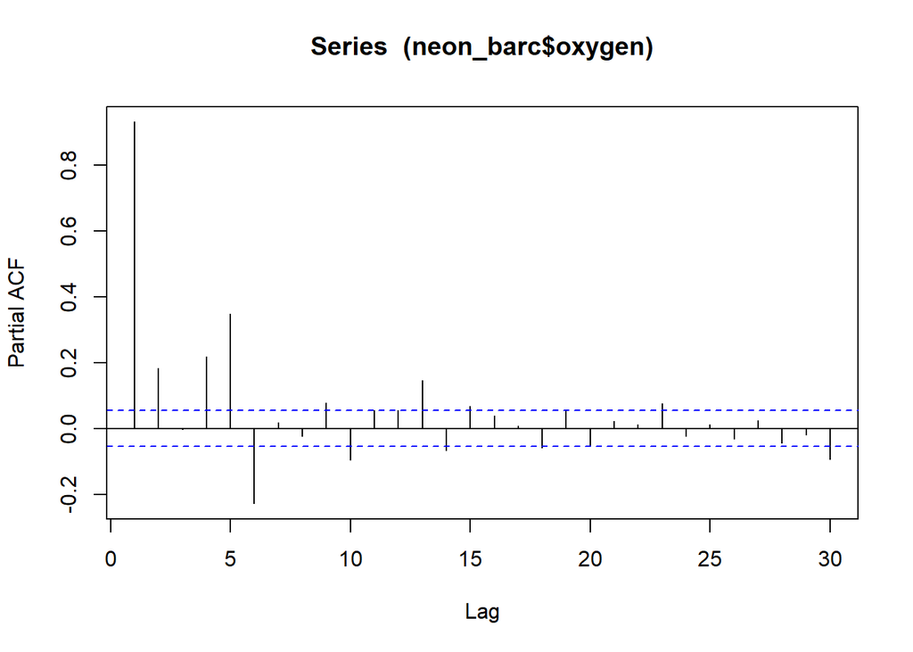